# Segmentasi Customers dengan K-Means

*Muhamad Nurhikmat Zain*

Customer segmentation adalah proses membagi basis pelanggan perusahaan ke dalam kelompok-kelompok yang lebih kecil berdasarkan karakteristik yang serupa. Tujuan dari segmentasi pelanggan adalah untuk memahami lebih baik kebutuhan dan preferensi pelanggan sehingga perusahaan dapat menargetkan strategi pemasaran, penjualan, dan layanan mereka dengan lebih efektif.

## Import Library

```python
import warnings
warnings.filterwarnings('ignore', category=FutureWarning)

import numpy as np #komputasi numerik
import pandas as pd #manipulasi, dataframe, analisis
import scipy

import matplotlib.pyplot as plt #visualisasi
import seaborn as sns #visualisasi
sns.set()

from sklearn.preprocessing import StandardScaler  #ml
from sklearn.cluster import KMeans #ml

import pickle #save model
```

Fungsi Utama dari Library library yang digunakan

- Numpy dan Pandas: Untuk manipulasi dan analisis data.
- Scipy: Untuk komputasi ilmiah dan analisis statistik.
- Matplotlib dan Seaborn: Untuk visualisasi data.
- Sklearn: Untuk penerapan algoritma machine learning dan preprocessing data.
- Pickle: Untuk menyimpan model machine learning atau objek Python lainnya ke disk untuk digunakan nanti.

Library-library ini sering digunakan bersama dalam alur kerja data science dan machine learning untuk mempersiapkan data, menerapkan algoritma, dan memvisualisasikan hasil.

## Import Data

Data yang digunakan adalah data customer pada perusahaan X

```python
df_cluster = pd.read_csv('segmentation data.csv', sep=';', index_col=0)
df_cluster.head()
```

| ID | Jenis Kelamin | Marital status | Usia | Pendidikan | Pendapatan | Pekerjaan | Settlement size |
| --- | --- | --- | --- | --- | --- | --- | --- |
| 100000001 | Pria | Belum Menikah | 67 | S1 | 124670 | Amatir | Big |
| 100000002 | Wanita | Menikah | 22 | SMA | 150773 | Amatir | Big |
| 100000003 | Pria | Belum Menikah | 49 | SMA | 89210 | Tidak Bekerja | Small |
| 100000004 | Pria | Belum Menikah | 45 | SMA | 171565 | Amatir | Mid |
| 100000005 | Pria | Belum Menikah | 53 | SMA | 149031 | Amatir | Mid |

```python
print("Jumlah baris:", df_cluster.shape[0])
print("Jumlah kolom:", df_cluster.shape[1])
```

```
Jumlah baris: 2000
Jumlah kolom: 7
```

```python
# Menggunakan loop untuk mendapatkan nilai unik dari setiap kolom
for column in df_cluster.columns:
    unique_values = df_cluster[column].unique()
    print(f"Unique values in column '{column}': {unique_values}")
```

```
Unique values in column 'Jenis Kelamin': ['Pria' 'Wanita']
Unique values in column 'Marital status': ['Belum Menikah' 'Menikah']
Unique values in column 'Usia': [67 22 49 45 53 35 61 28 25 24 60 32 44 31 48 26 36 39 42 34 63 27 30 57
 33 37 58 23 29 52 50 46 51 41 40 66 47 56 54 20 21 38 70 65 74 68 43 55
 64 75 19 62 59 73 72 76 71 18]
Unique values in column 'Pendidikan': ['S1' 'SMA' 'Unknown' 'S2']
Unique values in column 'Pendapatan': [124670 150773  89210 ...  86400  97968  68416]
Unique values in column 'Pekerjaan': ['Amatir' 'Tidak Bekerja' 'Proffesional']
Unique values in column 'Settlement size': ['Big' 'Small' 'Mid']
```

Data customer memiliki 7 variabel atau feature dengan 2000 customers.

- Jenis kelamin: Pria, Wanita
- Marital status: Belum Menikah, Menikah
- Usia
- Pendidikan: Unknown, SMA, S1, S2
- Pekerjaan: Tidak Bekerja, Amatir, Proffesional
- Settlement size: Small, Mid, Big

## Data Cleaning

Data cleaning digunakan untuk mempersiapkan data sebelum melakukan analisis lebih lanjut atau penerapan model machine learning. Data cleaning melibatkan beberapa langkah penting seperti mengatasi nilai yang hilang, mengoreksi atau menghapus data yang tidak valid, mengubah format data, dan lain-lain.

a. Cek tipe data

```python
# cek type data
df_cluster.dtypes
```

```
Jenis Kelamin      object
Marital status     object
Usia                int64
Pendidikan         object
Pendapatan          int64
Pekerjaan          object
Settlement size    object
dtype: object
```

Tipe data untuk variabel pendapatan dan usia adalah numerik (interval dan rasio). Sedangkan variabel lainnya adalah string/kategori (nominal dan ordinal)

b. Cek missing value

```python
# cek missing values
df_cluster.isnull().sum()
```

```
Jenis Kelamin      0
Marital status     0
Usia               0
Pendidikan         0
Pendapatan         0
Pekerjaan          0
Settlement size    0
dtype: int64
```

Tidak ada nilai missing value pada data customer. Sehingga tidak perlu dilakukan cara untuk mengatasinya.

```python
df_cluster.describe()
```

|  | Usia | Pendapatan |
| --- | --- | --- |
| count | 2000.000000 | 2000.000000 |
| mean | 35.909000 | 120954.419000 |
| std | 11.719402 | 38108.824679 |
| min | 18.000000 | 35832.000000 |
| 25% | 27.000000 | 97663.250000 |
| 50% | 33.000000 | 115548.500000 |
| 75% | 42.000000 | 138072.250000 |
| max | 76.000000 | 309364.000000 |

## Data Exploration

Eksplorasi data dilakukan untuk mengetahui insight apa saja yang dapat diperoleh dari data yang disajikan.

### Eksplorasi dan Visualisasi data

Statistik Deskriptif pada Variabel dengan tipe interval dan rasio

```python
interval_rasio = df_cluster[['Usia', 'Pendapatan']]
nominal_ordinal = df_cluster[['Jenis Kelamin', 'Marital status', 'Pendidikan', 'Pekerjaan', 'Settlement size']]
```

```python
interval_rasio.describe()
```

|  | Usia | Pendapatan |
| --- | --- | --- |
| count | 2000.000000 | 2000.000000 |
| mean | 35.909000 | 120954.419000 |
| std | 11.719402 | 38108.824679 |
| min | 18.000000 | 35832.000000 |
| 25% | 27.000000 | 97663.250000 |
| 50% | 33.000000 | 115548.500000 |
| 75% | 42.000000 | 138072.250000 |
| max | 76.000000 | 309364.000000 |

Statistik Deskriptif pada Variabel dengan tipe nominal dan ordinal

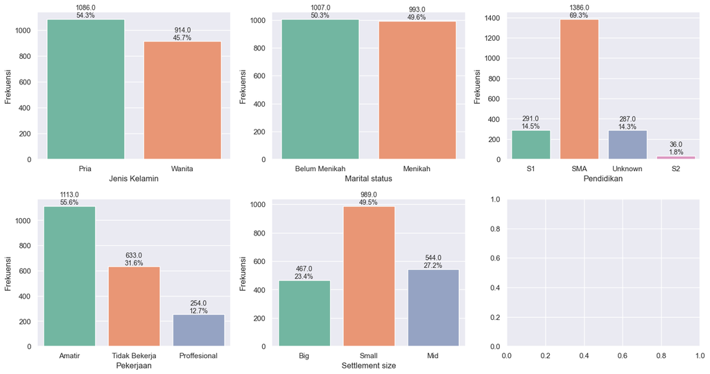

```python
# Menentukan tata letak subplots
fig, axes = plt.subplots(nrows=2, ncols=3, figsize=(15, 8))

# Iterasi melalui setiap kolom
for i, column in enumerate(nominal_ordinal.columns):
    row = i // 3  # Baris ke berapa (0 atau 1)
    col = i % 3   # Kolom ke berapa (0, 1, atau 2)

    # Membuat countplot di setiap subplot
    ax = sns.countplot(x=column, data=nominal_ordinal, palette='Set2', ax=axes[row, col])
    ax.set_xlabel(column)
    ax.set_ylabel('Frekuensi')

    # Menambahkan label angka dan proporsi di atas setiap batang
    total = len(nominal_ordinal[column])
    for p in ax.patches:
        height = p.get_height()
        ax.text(p.get_x() + p.get_width() / 2.0, height, f'{height}\n{height/total:.1%}',
                ha='center', va='bottom', fontsize=10)

# Mengatur layout dan menampilkan plot
plt.tight_layout()
plt.show()
```

Terlihat bahwa customer yang dominan yaitu customer dengan jenis kelamin pria, belum menikah, berpendidikan SMA, skill pekerjaan amatir dan settlement size kecil

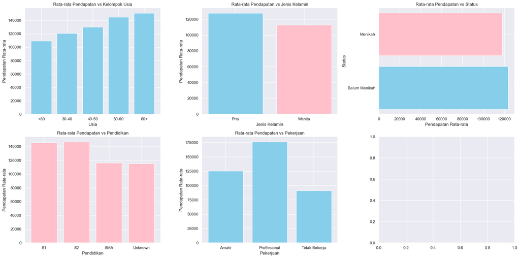

```python
### Membuat figure dan axes
df_cluster1 = pd.read_csv('segmentation data.csv', sep=';', index_col=0)
fig, axs = plt.subplots(nrows=2, ncols=3, figsize=(20, 10))

## Usia vs rata-rata pendapatan
# Pengelompokan data berdasarkan kelompok usia
bins = [0, 30, 40, 50, 60, 100]
labels = ['<30', '30-40', '40-50', '50-60', '60+']
df_cluster1['Kelompok Usia'] = pd.cut(df_cluster1['Usia'], bins=bins, labels=labels)
usia_pendapatan = df_cluster1['Kelompok Usia']

# Menghitung rata-rata pendapatan per kelompok usia
avg_income_by_age_group = df_cluster1.groupby('Kelompok Usia')['Pendapatan'].mean().reset_index()

# Mengurutkan DataFrame berdasarkan 'Kelompok Usia'
df_cluster1.sort_values('Kelompok Usia', inplace=True)
df_cluster1.reset_index(drop=True, inplace=True)

# Membuat bar chart usia vs rata2 pendapatan
axs[0,0].bar(avg_income_by_age_group['Kelompok Usia'], avg_income_by_age_group['Pendapatan'], color='skyblue')
axs[0,0].set_xlabel('Usia')
axs[0,0].set_ylabel('Pendapatan Rata-rata')
axs[0,0].set_title('Rata-rata Pendapatan vs Kelompok Usia')

## Jenis kelamin vs rata-rata pendapatan
# Menghitung rata-rata pendapatan berdasarkan jenis kelamin
avg_income_by_gender = df_cluster1.groupby('Jenis Kelamin')['Pendapatan'].mean().reset_index()

# Membuat bar chart jenis kelamin vs rata2 pendapatan
axs[0,1].bar(avg_income_by_gender['Jenis Kelamin'], avg_income_by_gender['Pendapatan'], color=['skyblue', 'pink'])
axs[0,1].set_xlabel('Jenis Kelamin')
axs[0,1].set_ylabel('Pendapatan Rata-rata')
axs[0,1].set_title('Rata-rata Pendapatan vs Jenis Kelamin')

## Status vs rata-rata pendapatan
# Menghitung rata-rata pendapatan berdasarkan jenis kelamin
avg_income_by_marital = df_cluster1.groupby('Marital status')['Pendapatan'].mean().reset_index()

# Membuat bar chart
axs[0,2].barh(avg_income_by_marital['Marital status'], avg_income_by_marital['Pendapatan'], color=['skyblue', 'pink'])
axs[0,2].set_xlabel('Pendapatan Rata-rata')
axs[0,2].set_ylabel('Status')
axs[0,2].set_title('Rata-rata Pendapatan vs Status')

## Pendidikan vs rata-rata pendapatan
# Menghitung rata-rata pendapatan berdasarkan jenis kelamin
avg_income_by_pendidikan = df_cluster1.groupby('Pendidikan')['Pendapatan'].mean().reset_index()

# Membuat bar chart
axs[1,0].bar(avg_income_by_pendidikan['Pendidikan'], avg_income_by_pendidikan['Pendapatan'], color=['pink'])
axs[1,0].set_xlabel('Pendidikan')
axs[1,0].set_ylabel('Pendapatan Rata-rata')
axs[1,0].set_title('Rata-rata Pendapatan vs Pendidikan')

## Pekerjaan vs rata-rata pendapatan
# Menghitung rata-rata pendapatan berdasarkan jenis kelamin
avg_income_by_pekerjaan = df_cluster1.groupby('Pekerjaan')['Pendapatan'].mean().reset_index()

# Membuat bar chart
axs[1,1].bar(avg_income_by_pekerjaan['Pekerjaan'], avg_income_by_pekerjaan['Pendapatan'], color=['skyblue'])
axs[1,1].set_xlabel('Pekerjaan')
axs[1,1].set_ylabel('Pendapatan Rata-rata')
axs[1,1].set_title('Rata-rata Pendapatan vs Pekerjaan')

# Adjust layout
plt.tight_layout()

# Menampilkan plot
plt.show()
```

```python
df_cluster.head()
```

| ID | Jenis Kelamin | Marital status | Usia | Pendidikan | Pendapatan | Pekerjaan | Settlement size |
| --- | --- | --- | --- | --- | --- | --- | --- |
| 100000001 | Pria | Belum Menikah | 67 | S1 | 124670 | Amatir | Big |
| 100000002 | Wanita | Menikah | 22 | SMA | 150773 | Amatir | Big |
| 100000003 | Pria | Belum Menikah | 49 | SMA | 89210 | Tidak Bekerja | Small |
| 100000004 | Pria | Belum Menikah | 45 | SMA | 171565 | Amatir | Mid |
| 100000005 | Pria | Belum Menikah | 53 | SMA | 149031 | Amatir | Mid |

```python
df_cluster1.head()
```

|  | Jenis Kelamin | Marital status | Usia | Pendidikan | Pendapatan | Pekerjaan | Settlement size | Kelompok Usia |
| --- | --- | --- | --- | --- | --- | --- | --- | --- |
| 0 | Pria | Belum Menikah | 27 | Unknown | 147968 | Amatir | Mid | <30 |
| 1 | Pria | Menikah | 24 | SMA | 94249 | Proffesional | Big | <30 |
| 2 | Pria | Menikah | 27 | SMA | 180940 | Proffesional | Mid | <30 |
| 3 | Pria | Menikah | 20 | SMA | 107270 | Amatir | Big | <30 |
| 4 | Pria | Menikah | 30 | SMA | 90500 | Proffesional | Big | <30 |

### Korelasi Pearson

Variabel dengan tipe data string tidak bisa dilakukan komputasi analisis kluster, oleh karenanya perlu merubahnya menjadi tipe numerik untuk keperluan analisis.

```python
df_cluster.replace({
    'Jenis Kelamin': {'Pria': 0, 'Wanita': 1},
    'Marital status': {'Belum Menikah': 0, 'Menikah': 1},
    'Pendidikan': {'Unknown': 0, 'SMA': 1, 'S1': 2, 'S2': 3},
    'Pekerjaan': {'Tidak Bekerja': 0, 'Amatir': 1, 'Proffesional': 2},
    'Settlement size': {'Small': 0, 'Mid': 1, 'Big': 2}
}, inplace=True)
df_cluster.head()
```

| ID | Jenis Kelamin | Marital status | Usia | Pendidikan | Pendapatan | Pekerjaan | Settlement size |
| --- | --- | --- | --- | --- | --- | --- | --- |
| 100000001 | 0 | 0 | 67 | 2 | 124670 | 1 | 2 |
| 100000002 | 1 | 1 | 22 | 1 | 150773 | 1 | 2 |
| 100000003 | 0 | 0 | 49 | 1 | 89210 | 0 | 0 |
| 100000004 | 0 | 0 | 45 | 1 | 171565 | 1 | 1 |
| 100000005 | 0 | 0 | 53 | 1 | 149031 | 1 | 1 |

Korelasi Pearson mengukur hubungan linear antara dua atau lebih variabel numerik

```python
# Korelasi Pearson
interval_rasio1 = df_cluster[['Usia', 'Pendapatan']]
correlation_pearson = interval_rasio1.corr(method='pearson')
correlation_pearson
```

|  | Usia | Pendapatan |
| --- | --- | --- |
| Usia | 1.00000 | 0.34061 |
| Pendapatan | 0.34061 | 1.00000 |

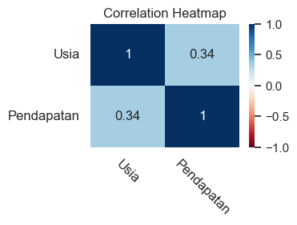

```python
#Plot a heatmap
plt.figure(figsize = (3, 2))
s = sns.heatmap(correlation_pearson,
               annot = True, #write the data value in each cell
               cmap = 'RdBu', #color scheme
               vmin = -1,
               vmax = 1) #set the higher and lower bound
s.set_yticklabels(s.get_yticklabels(), rotation = 0, fontsize = 12)
s.set_xticklabels(s.get_xticklabels(), rotation = -45, fontsize = 12)
plt.title('Correlation Heatmap')
plt.show()
```

Nilai korelasi sebesar 0.34 menunjukkan bahwa usia dengan pendatapan memiliki hubungan yang lemah.

### Korelasi Rank Spearman

Korelasi Spearman mengukur hubungan monotonic antara dua variabel kategori, yang berarti bahwa korelasi ini tidak membutuhkan hubungan yang linear.

```python
nominal_ordinal1 = df_cluster[['Jenis Kelamin', 'Marital status', 'Pendidikan', 'Pekerjaan', 'Settlement size']]
correlation_rank_spearman = nominal_ordinal1.corr(method='spearman')
correlation_rank_spearman
```

|  | Jenis Kelamin | Marital status | Pendidikan | Pekerjaan | Settlement size |
| --- | --- | --- | --- | --- | --- |
| Jenis Kelamin | 1.000000 | 0.566511 | 0.243693 | -0.198652 | -0.303118 |
| Marital status | 0.566511 | 1.000000 | 0.376785 | -0.022700 | -0.093684 |
| Pendidikan | 0.243693 | 0.376785 | 1.000000 | 0.050204 | 0.033585 |
| Pekerjaan | -0.198652 | -0.022700 | 0.050204 | 1.000000 | 0.595971 |
| Settlement size | -0.303118 | -0.093684 | 0.033585 | 0.595971 | 1.000000 |

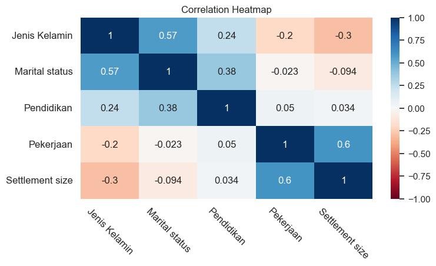

```python
#Plot a heatmap
plt.figure(figsize = (8, 4))
s = sns.heatmap(correlation_rank_spearman,
               annot = True, #write the data value in each cell
               cmap = 'RdBu', #color scheme
               vmin = -1,
               vmax = 1) #set the higher and lower bound
s.set_yticklabels(s.get_yticklabels(), rotation = 0, fontsize = 12)
s.set_xticklabels(s.get_xticklabels(), rotation = -45, fontsize = 12)
plt.title('Correlation Heatmap')
plt.show()
```

Terdapat beberapa pasangan variabel yang memiliki hubungan yang lemah sampai kuat yaitu:

- Marital status vs Pendidikan: 0.38 (hubungan lemah)
- Marital status vs Jenis kelamin: 0.57 (hubungan sedang)
- Pekerjaan vs Settlement size: 0.6 (kuat)

Sedangkan sisa pasangan variabel yang lainnya memiliki hubungan yang sangat lemah. Sehingga tanpa mengurangi informasi yang ada memungkinkan untuk mereduksi beberapa variabel yang memiliki hubungan yang sangat lemah. Namun untuk kesempatan kali ini akan menggunakan keseluruhan variabel pada data.

## Analisis Kluster

*Analisis cluster adalah teknik statistik yang digunakan untuk mengelompokkan objek atau data ke dalam grup atau cluster yang sedemikian rupa sehingga objek-objek dalam satu cluster memiliki kesamaan tertentu dan berbeda dengan objek-objek di cluster lain. Ini adalah metode eksploratif yang tidak memiliki variabel target*  
Tujuan Analisis Cluster

- Mengidentifikasi Kelompok: Menemukan grup yang memiliki kesamaan karakteristik.
- Mengurangi Dimensi Data: Mengurangi kompleksitas data dengan mengelompokkan data yang serupa.
- Mendukung Pengambilan Keputusan: Memahami segmentasi dalam data dapat membantu dalam pengambilan keputusan bisnis dan strategi pemasaran.

### Standarisasi data

Standard Scaler adalah metode yang umum digunakan untuk melakukan standarisasi data. Standarisasi ini berguna untuk mengubah distribusi data sehingga memiliki rata-rata 0 dan variansi 1. Rumus matematika untuk Standard Scaler adalah sebagai berikut:

Pada konteks Scikit-Learn, fit_transform() dilakukan dalam dua tahap:

1. Fit: Pada tahap ini, StandardScaler menghitung nilai rata-rata (𝜇) dan standar deviasi (𝜎) dari setiap fitur di dataset yang diberikan.
2. Transform: Setelah perhitungan nilai rata-rata dan standar deviasi selesai, data diubah (scaled) menggunakan rumus di atas untuk setiap titik data.

Secara umum, dalam notasi matematika, transformasi ini dapat direpresentasikan sebagai:

[figure not shown]

```python
scaler = StandardScaler() #Create an instance
cluster_std = scaler.fit_transform(df_cluster) #Apply the fit transformation
```

### K-Means

#### Grafik Elbow

Grafik elbow digunakan sebagai dasar justifikasi dalam menentukan jumlah cluster menggunakan SSE

[figure not shown]

```python
# Perform K-means clustering
# Consider 1 to 10 clusters
wcss = []
for i in range(1,11):
    kmeans = KMeans(n_clusters = i,
                    init = 'k-means++',
                    random_state = 42)
    kmeans.fit(cluster_std)
    wcss.append(kmeans.inertia_)
```

Penjelasan:  
wcss: List yang digunakan untuk menyimpan nilai Within-Cluster Sum of Squares (WCSS) untuk setiap jumlah cluster dari 1 hingga 10.  
KMeans(n_clusters=i, init='k-means++', random_state=42): Membuat objek KMeans dengan i cluster, menggunakan inisialisasi 'k-means++' untuk memilih pusat cluster secara cerdas, dan random_state=42 untuk hasil yang dapat direplikasi.  
kmeans.fit(cluster_std): Melatih model KMeans pada data yang telah diubah (scaled) cluster_std.  
wcss.append(kmeans.inertia_): Menambahkan nilai WCSS dari model KMeans yang dilatih ke dalam list wcss.

Within-Cluster Sum of Squares (WCSS) adalah ukuran varians dalam setiap klaster. Ini adalah jumlah kuadrat dari jarak antara setiap titik data dalam klaster dan pusat klaster (centroid) klaster tersebut. WCSS digunakan untuk menilai seberapa baik data dikelompokkan dalam klaster yang berbeda.

Semakin kecil nilai WCSS, semakin baik klaster tersebut menggambarkan data. Namun, seiring bertambahnya jumlah klaster, WCSS akan cenderung menurun. Oleh karena itu, Elbow Method digunakan untuk menemukan jumlah klaster optimal, di mana penurunan WCSS tidak lagi signifikan setelah titik tertentu.

init='k-means++' adalah parameter yang digunakan dalam algoritma K-means clustering untuk menginisialisasi centroid awal dari klaster. Tujuannya adalah untuk memperbaiki kelemahan dari metode inisialisasi centroid secara acak, yang dapat menyebabkan hasil clustering yang buruk atau konvergensi lambat.

Parameter random_state adalah nilai seed untuk generator bilangan acak. Dengan menentukan nilai random_state, kita dapat memastikan bahwa hasil yang diperoleh dapat direplikasi. Ini berarti setiap kali menjalankan algoritma dengan random_state=42, akan mendapatkan hasil yang sama.

kmeans.fit(cluster_std): Melatih model K-means pada data yang distandarisasi.

wcss.append(kmeans.inertia_): Menyimpan nilai WCSS dari model yang dilatih ke dalam daftar wcss.

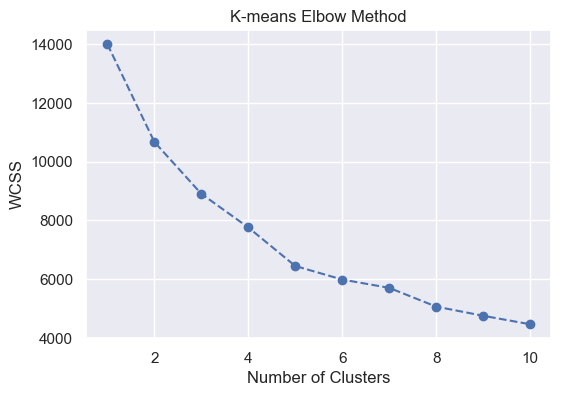

```python
# Plot the Within Cluster Sum of Squares for the different number of clusters
plt.figure(figsize = (6,4))
plt.plot(range(1, 11), wcss, marker = 'o', linestyle = '--')
plt.xlabel('Number of Clusters')
plt.ylabel('WCSS')
plt.title('K-means Elbow Method')
plt.show()
```

#### Model K-Means

Akan dibuat model K-Means dengan parameter jumlah kluster = 4

```python
kmeans = KMeans(n_clusters = 4, init = 'k-means++', random_state = 42)
kmeans.fit(cluster_std)
```

```
KMeans(n_clusters=4, random_state=42)
```

Selanjutnya adalah menggabungkan seluruh referensi dan objek k-means ini supaya bisa digunakan untuk mengolah data baru dan berguna.

```python
df_segm_kmeans = df_cluster.copy()
df_segm_kmeans['Cluster'] = kmeans.labels_
```

```python
df_segm_kmeans.head()
```

| ID | Jenis Kelamin | Marital status | Usia | Pendidikan | Pendapatan | Pekerjaan | Settlement size | Cluster |
| --- | --- | --- | --- | --- | --- | --- | --- | --- |
| 100000001 | 0 | 0 | 67 | 2 | 124670 | 1 | 2 | 3 |
| 100000002 | 1 | 1 | 22 | 1 | 150773 | 1 | 2 | 2 |
| 100000003 | 0 | 0 | 49 | 1 | 89210 | 0 | 0 | 0 |
| 100000004 | 0 | 0 | 45 | 1 | 171565 | 1 | 1 | 3 |
| 100000005 | 0 | 0 | 53 | 1 | 149031 | 1 | 1 | 3 |

```python
df_segm_analysis = df_segm_kmeans.groupby(['Cluster']).mean()
df_segm_analysis
```

| Cluster | Jenis Kelamin | Marital status | Usia | Pendidikan | Pendapatan | Pekerjaan | Settlement size |
| --- | --- | --- | --- | --- | --- | --- | --- |
| 0 | 0.066543 | 0.000000 | 33.240296 | 0.489834 | 109932.785582 | 0.639556 | 0.611830 |
| 1 | 0.868254 | 0.785714 | 32.928571 | 1.163492 | 98466.955556 | 0.384127 | 0.006349 |
| 2 | 0.691099 | 0.979058 | 29.060209 | 1.104712 | 126838.926702 | 1.107330 | 1.324607 |
| 3 | 0.149888 | 0.277405 | 49.192394 | 1.467562 | 160958.722595 | 1.364653 | 1.425056 |

Kolom Jenis Kelamin menunjukkan dengan angka 0 mewakili pria dan angka 1 mewakili wanita. Pada cluster 1 bernilai 0.868, artinya cluster tersebut kebanyakan berisi profil dengan jenis kelamin wanita.

```python
# Compute the size and proportions of the four clusters
df_segm_analysis['N Obs'] = \
df_segm_kmeans[['Cluster','Jenis Kelamin']].groupby(['Cluster']).count()
df_segm_analysis['Prop Obs'] = \
df_segm_analysis['N Obs'] / df_segm_analysis['N Obs'].sum()
df_segm_analysis.rename({0:'fewer opportunities',
                         1:'standard',
                         2:'career focused',
                         3:'well-off'})
```

| Cluster | Jenis Kelamin | Marital status | Usia | Pendidikan | Pendapatan | Pekerjaan | Settlement size | N Obs | Prop Obs |
| --- | --- | --- | --- | --- | --- | --- | --- | --- | --- |
| fewer opportunities | 0.066543 | 0.000000 | 33.240296 | 0.489834 | 109932.785582 | 0.639556 | 0.611830 | 541 | 0.2705 |
| standard | 0.868254 | 0.785714 | 32.928571 | 1.163492 | 98466.955556 | 0.384127 | 0.006349 | 630 | 0.3150 |
| career focused | 0.691099 | 0.979058 | 29.060209 | 1.104712 | 126838.926702 | 1.107330 | 1.324607 | 382 | 0.1910 |
| well-off | 0.149888 | 0.277405 | 49.192394 | 1.467562 | 160958.722595 | 1.364653 | 1.425056 | 447 | 0.2235 |

```python
df_segm_kmeans['Labels'] = df_segm_kmeans['Cluster'].map({0:'fewer opportunities',
                                                          1:'standard',
                                                          2:'career focused',
                                                          3:'well-off'})
df_segm_kmeans.head(10)
```

| ID | Jenis Kelamin | Marital status | Usia | Pendidikan | Pendapatan | Pekerjaan | Settlement size | Cluster | Labels |
| --- | --- | --- | --- | --- | --- | --- | --- | --- | --- |
| 100000001 | 0 | 0 | 67 | 2 | 124670 | 1 | 2 | 3 | well-off |
| 100000002 | 1 | 1 | 22 | 1 | 150773 | 1 | 2 | 2 | career focused |
| 100000003 | 0 | 0 | 49 | 1 | 89210 | 0 | 0 | 0 | fewer opportunities |
| 100000004 | 0 | 0 | 45 | 1 | 171565 | 1 | 1 | 3 | well-off |
| 100000005 | 0 | 0 | 53 | 1 | 149031 | 1 | 1 | 3 | well-off |
| 100000006 | 0 | 0 | 35 | 1 | 144848 | 0 | 0 | 0 | fewer opportunities |
| 100000007 | 0 | 0 | 53 | 1 | 156495 | 1 | 1 | 3 | well-off |
| 100000008 | 0 | 0 | 35 | 1 | 193621 | 2 | 1 | 3 | well-off |
| 100000009 | 0 | 1 | 61 | 2 | 151591 | 0 | 0 | 3 | well-off |
| 100000010 | 0 | 1 | 28 | 1 | 174646 | 2 | 0 | 2 | career focused |

Menamakan cluster dengan karakteristik yang lebih mudah dimengerti.

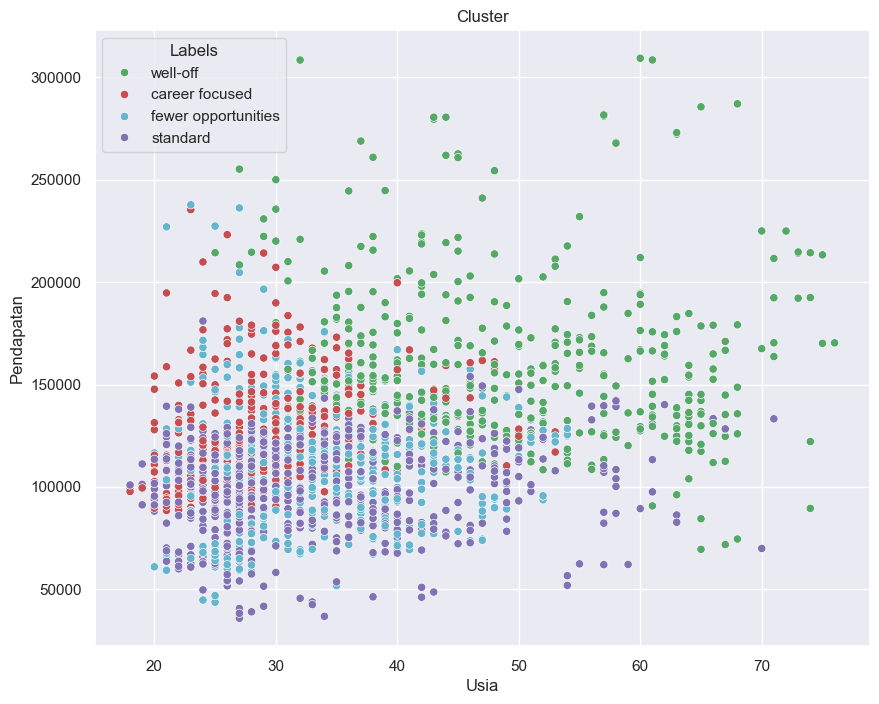

```python
x_axis = df_segm_kmeans['Usia']
y_axis = df_segm_kmeans['Pendapatan']
plt.figure(figsize = (10, 8))
sns.scatterplot(x=x_axis, y=y_axis, hue = df_segm_kmeans['Labels'], palette = ['g', 'r', 'c', 'm'])
plt.title('Cluster')
plt.show()
```

# Aplikasi Model pada Data Baru

```python
# klasifikasi new data
np.random.seed(31)
data = {
    'Pendapatan': np.random.randint(20000, 100000, size=1),
    'Marital status' : np.random.choice(['Belum Menikah', 'Menikah'], size=1),
    'Usia': np.random.randint(20, 70, size=1),
    'Jenis Kelamin': np.random.choice(['Pria', 'Wanita'], size=1),
    'Pendidikan': np.random.choice(['Unknown', 'SMA', 'S1', 'S2'], size=1),
    'Pekerjaan': np.random.choice(['Tidak Bekerja', 'Amatir', 'Proffesional'], size=1),
    'Settlement size': np.random.choice(['Small', 'Mid', 'Big'], size=1)
}

# Konversi ke DataFrame
df_dummy = pd.DataFrame(data)

# mengganti type data string menjadi numerik untuk keperluan analisis
df_dummy['Jenis Kelamin'] = df_dummy['Jenis Kelamin'].replace({'Pria': 0, 'Wanita': 1})
df_dummy['Marital status'] = df_dummy['Marital status'].replace({'Belum Menikah': 0, 'Menikah': 1})
df_dummy['Pendidikan'] = df_dummy['Pendidikan'].replace({'Unknown': 0, 'SMA': 1, 'S1': 2, 'S2': 3})
df_dummy['Pekerjaan'] = df_dummy['Pekerjaan'].replace({'Tidak Bekerja': 0, 'Amatir': 1, 'Proffesional': 2})
df_dummy['Settlement size'] = df_dummy['Settlement size'].replace({'Small': 0, 'Mid': 1, 'Big': 2})

# Contoh preprocessing untuk scaling menggunakan StandardScaler
from sklearn.preprocessing import StandardScaler
scaler = StandardScaler()
cluster_std = scaler.fit_transform(df_dummy)

# Gunakan KMeans yang telah di-train sebelumnya untuk memprediksi cluster
df_dummy['Cluster'] = kmeans.predict(cluster_std)
df_dummy['Labels'] = df_dummy['Cluster'].map({0:'fewer opportunities',
                                              1:'standard',
                                              2:'career focused',
                                              3:'well-off'})

df_dummy
```

|  | Pendapatan | Marital status | Usia | Jenis Kelamin | Pendidikan | Pekerjaan | Settlement size | Cluster | Labels |
| --- | --- | --- | --- | --- | --- | --- | --- | --- | --- |
| 0 | 73970 | 1 | 36 | 0 | 2 | 2 | 0 | 2 | career focused |